# Session3.2: Visualisation avec ggplot: Extension

Visseho Adjiwanou, PhD.

13 June 2021

# Extension

## Introduction

- Nous allons utiliser les données:
- dhs_ipv
- crsc_small

```r
library(tidyverse)
library(ggpubr)

dhs_ipv <- read_csv("../données/dhs_ipv.csv")

dhs_ipv<-
  dhs_ipv %>%
  mutate(beat_burnfood_cat = factor(ntile(beat_burnfood, 4), labels = c('très faible', 'faible', 'élevé', 'très élevé')),
         beat_goesout_cat = factor(ntile(beat_goesout, 4), labels = c('très faible', 'faible', 'élevé', 'très élevé')),
         sec_school_cat = factor(ntile(sec_school, 3), labels = c('pauvre', 'moyen', 'riche')),
         no_media_cat = factor(ntile(no_media, 3), labels = c('riche', 'moyen', 'pauvre')))


crsc96 <- read_csv("../données/cora-crsc1996-E-1996_F1.csv")

crsc96_small <-
  crsc96 %>%
  select(sexq, region, age, ageq, q1, q2, q3, q4, q44, q95) %>%
  mutate(sexe = factor(sexq, labels = c("Homme", "Femme")),
         q2_new = factor(q2, labels = c("totally agree", "agree somewhat", "DK/NA", "disagree somewhat", "totally disagree")))
```

## Introduction

- Plus dans aes : **mappage** : c'est une mise en relation entre un **attribut graphique du geom** et une variable du tableau de données.
- Changer les couleurs (*color*), la taille (*size*), la position (*position*), la transparence (*alpha*), le remplissage (*fill*)
- **Facets** : le **faceting** permet d’effectuer plusieurs fois le même graphique selon les valeurs d’une ou plusieurs variables qualitatives (notre *group_by*): facet_wrap, facet_grid
- Les **scales** : ils permettent de modifier la manière dont un attribut graphique va être relié aux valeurs d’une variable, et dont la légende correspondante va être affichée.
- Les **thèmes** : ils permettent de contrôler l’affichage de tous les éléments du graphique qui ne sont pas reliés aux données : **titres**, **grilles**, **fonds**, etc. https://ggplot2.tidyverse.org/reference/theme.html

# Exemples: Visualiser la distribution univariée: extension

## Exemples: Visualiser la distribution univariée: extension

- Plus dans aes : mappage
- Facets
- Représentation de plusieurs graphiques sur une même figure
- Les scales
- Les thèmes

## 1. Exemple: Plus dans aes

- A la différence de boxplot qui nous permet de comparer les distributions de manière compact entre différents groupes, les autres graphiques portaient sur l'ensemble de l'échantillon.
- Que faire pour comparer par exemple des histogrammes ou des diagrammes de barres de différents sous-échantillons?
- Vous devez pensez immédiatement à :
- **by_group**
- Malheureusement, il ne marche pas avec ggplot.
- Il faut utiliser le **mappage**
- Un mappage, dans ggplot2, est une mise en relation entre un **attribut graphique du geom** (position (*position*), couleur (*color*), taille (*size*)…) et une variable du tableau de données.

## Exemple: Plus dans aes

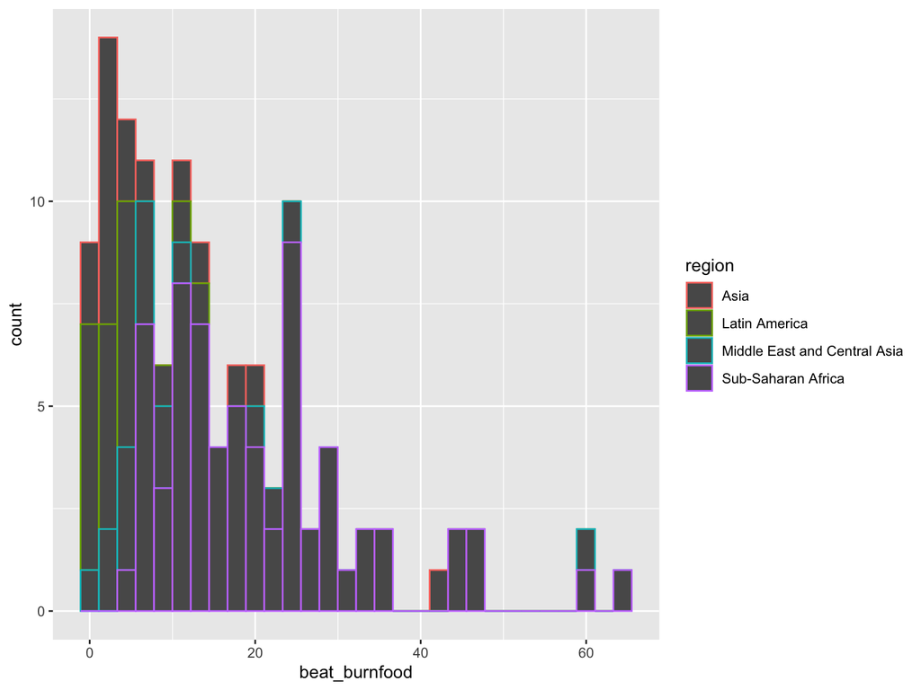

```r
ggplot(dhs_ipv) +
  geom_histogram(aes(x = beat_burnfood, color = region))
```

## 1. Exemple: Plus dans aes

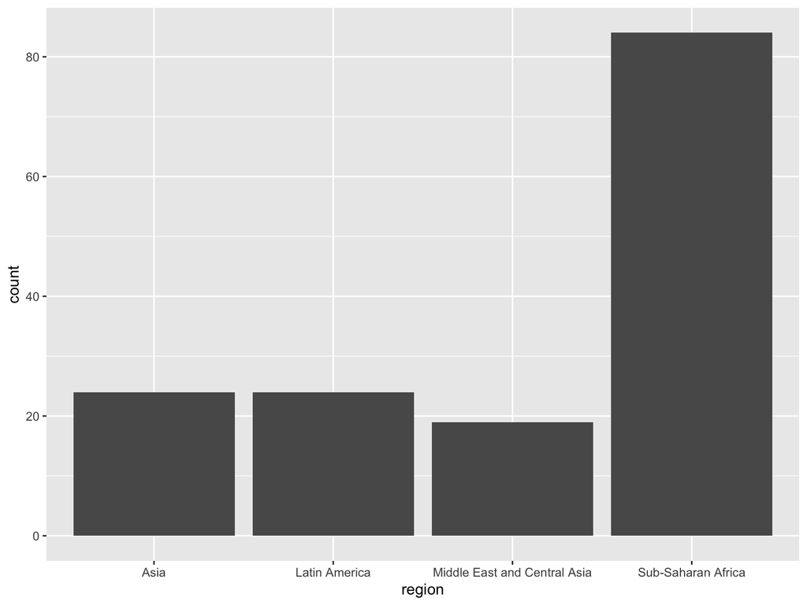

```r
c <- ggplot(dhs_ipv) +
  geom_bar(aes(x = region))

c
```

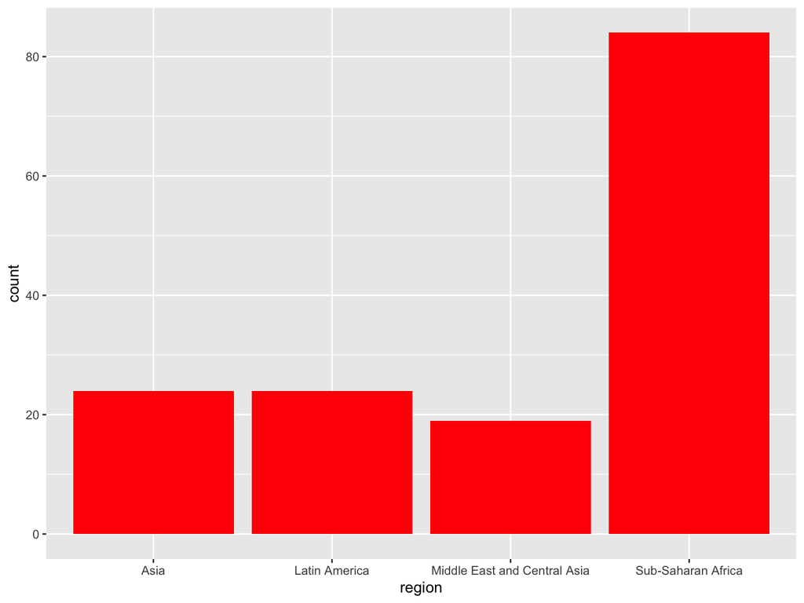

```r
d <- ggplot(dhs_ipv) +
  geom_bar(aes(x = region), fill = "red")

d
```

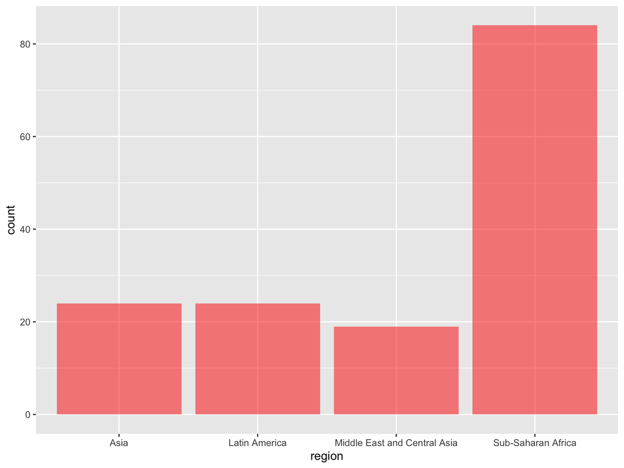

```r
e <- ggplot(dhs_ipv) +
  geom_bar(aes(x = region), fill = "red", alpha = 0.5)

e
```

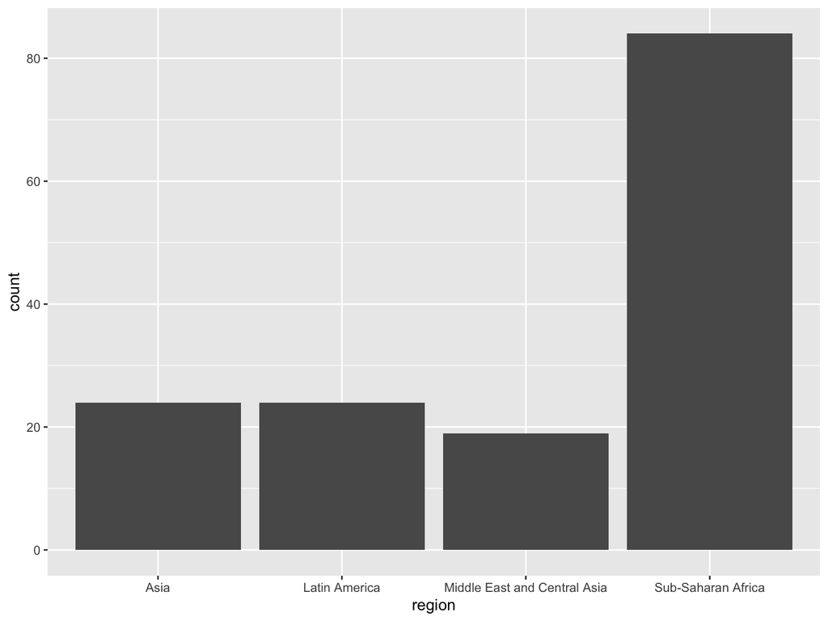

```r
ggplot(dhs_ipv) +
  geom_bar(aes(x = region))
```

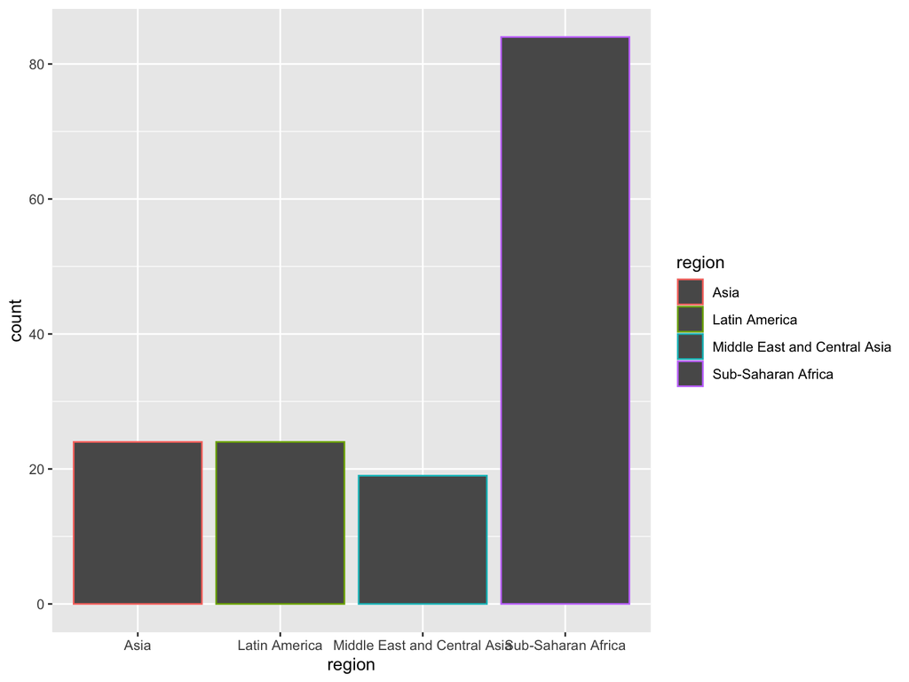

```r
ggplot(dhs_ipv) +
  geom_bar(aes(x = region,  color = region))
```

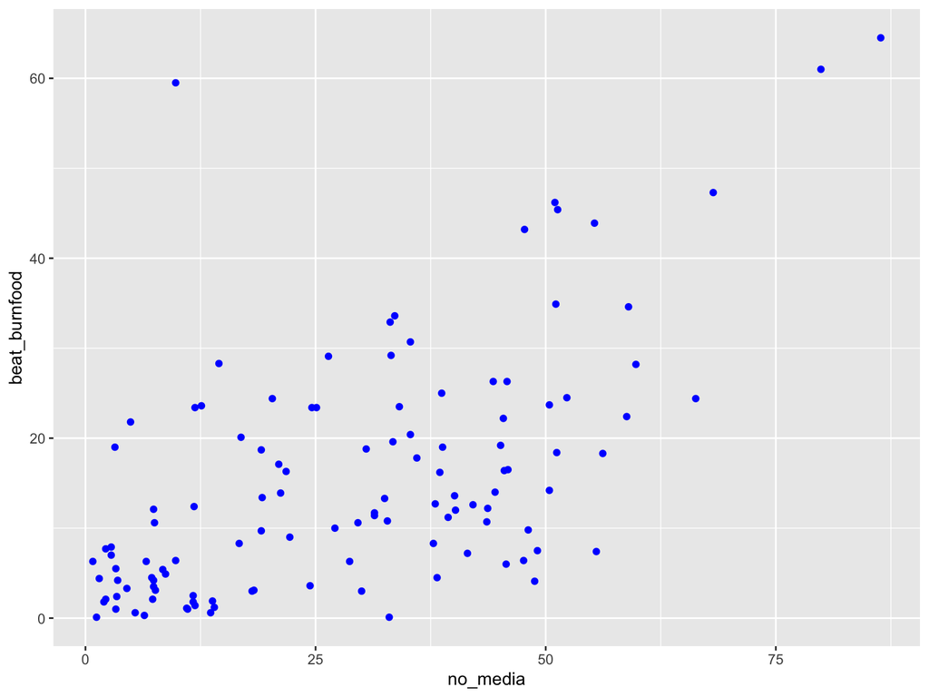

```r
ggplot(dhs_ipv) +
  geom_point(aes(x = no_media, y = beat_burnfood), color = "blue")
```

## 1. Exemple: Plus dans aes

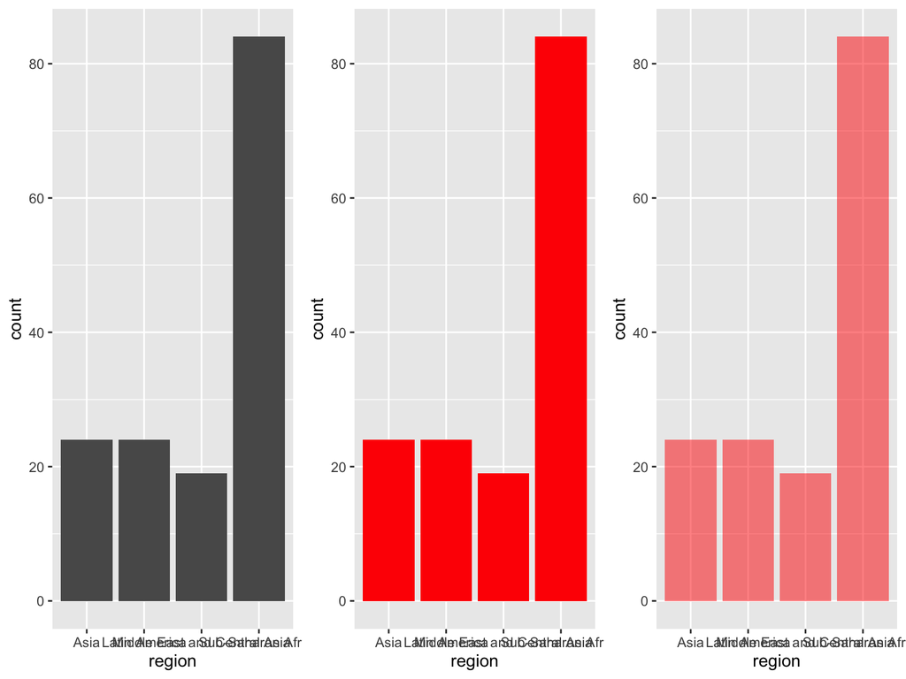

```r
ggarrange(c, d, e, ncol = 3)
```

# Exemple: Facets

## 2. Exemple: Facets

- Le **faceting** permet d’effectuer plusieurs fois le même graphique selon les valeurs d’une ou plusieurs variables qualitatives (notre *group_by*).

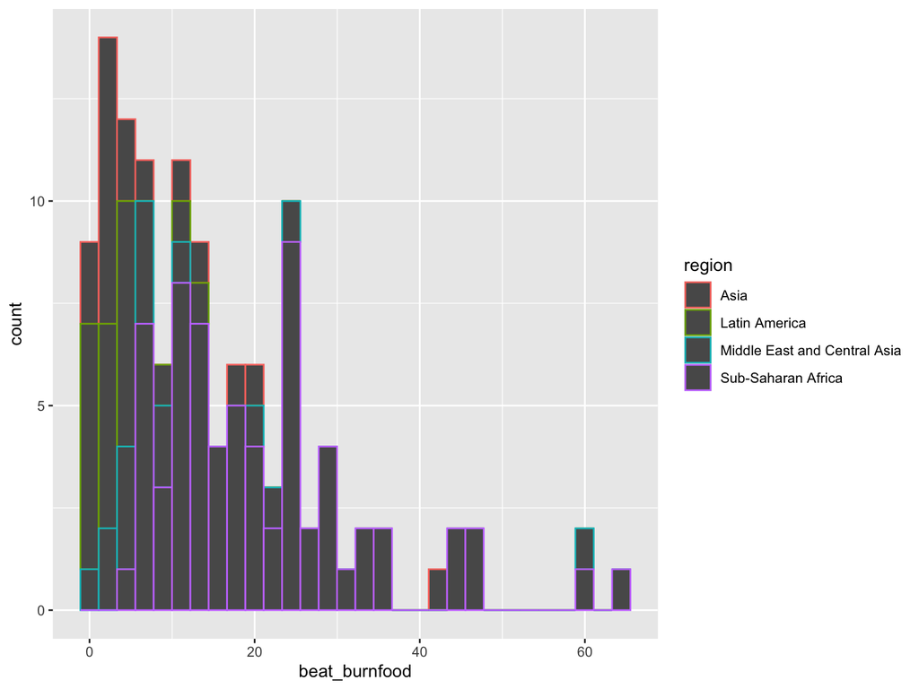

```r
ggplot(dhs_ipv) +
  geom_histogram(aes(x = beat_burnfood, color = region))
```

## 2. Exemple: Facets

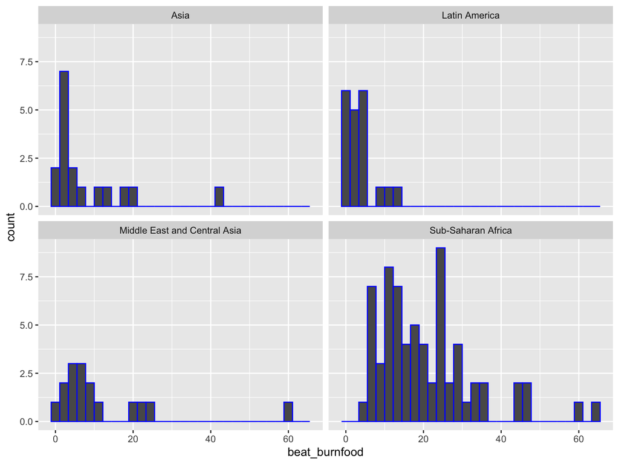

```r
ggplot(dhs_ipv) +
  geom_histogram(aes(x = beat_burnfood), color = "blue") +
  facet_wrap(~region)
```

## 2. Exemple: Facets

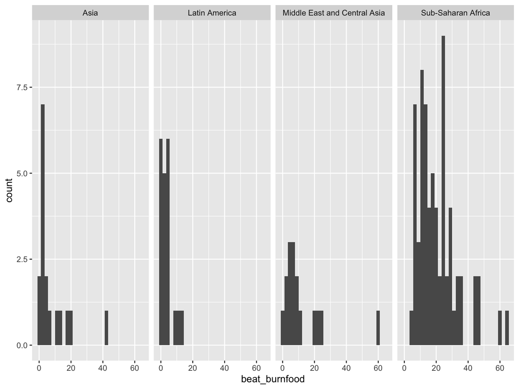

```r
ggplot(dhs_ipv) +
  geom_histogram(aes(x = beat_burnfood)) +
  facet_grid(.~region)
```

# Représentation de plusieurs graphiques sur une même figure

## Représentation de plusieurs graphiques sur une même figure

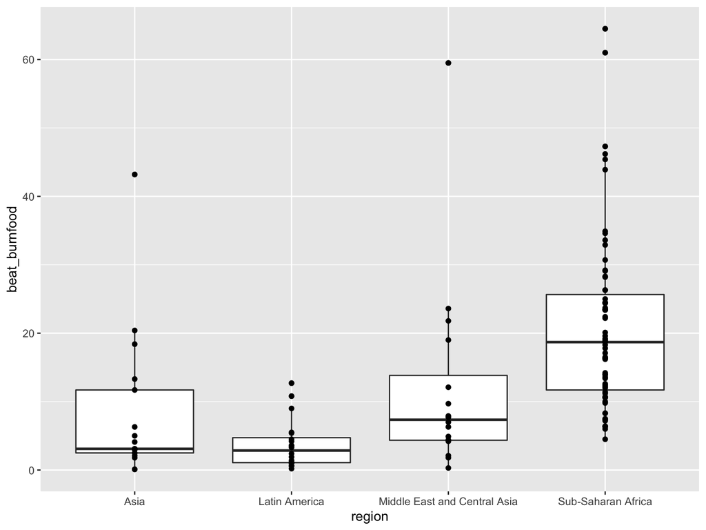

```r
ggplot(dhs_ipv) +
  geom_boxplot(aes(x = region, y = beat_burnfood)) +
  geom_point(aes(x = region, y = beat_burnfood))
```

```r
# Que faire si vous voulez que les points soient de couleur rouge?
# Que faire si vous voulez que les points de chaque région reflètent une même couleur?
# Que faire si à la place de points, vous voulez le nom des pays?
# Que faire si vous voulez mettre sur ce graphique la médiane de l'ensemble de l'échantillon?
```

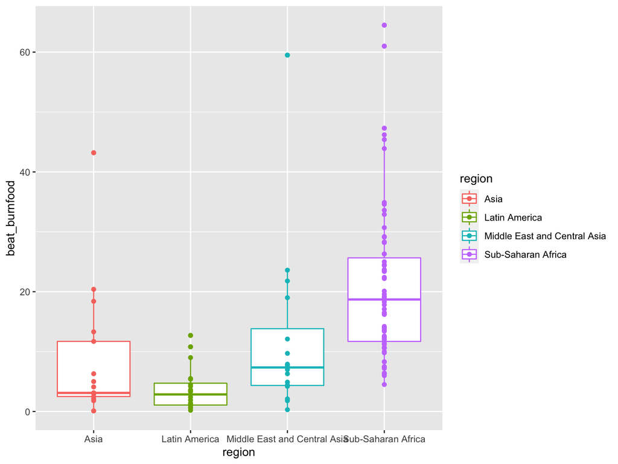

```r
ggplot(dhs_ipv, aes(x = region, y = beat_burnfood, color = region)) +
  geom_boxplot() +
  geom_point()
```

## Représentation de plusieurs graphiques sur une même figure

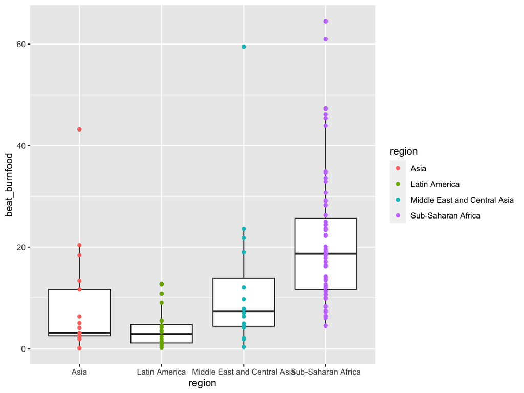

```r
b
```

# Les scales

## Les scales

- Les scales dans ggplot2 permettent de modifier la manière dont un attribut graphique va être relié aux valeurs d’une variable, et dont la légende correspondante va être affichée.
- Par exemple, pour l’attribut `color`, on pourra définir la palette de couleur utilisée. Pour `size`, les tailles minimales et maximales, etc.

## Les scales

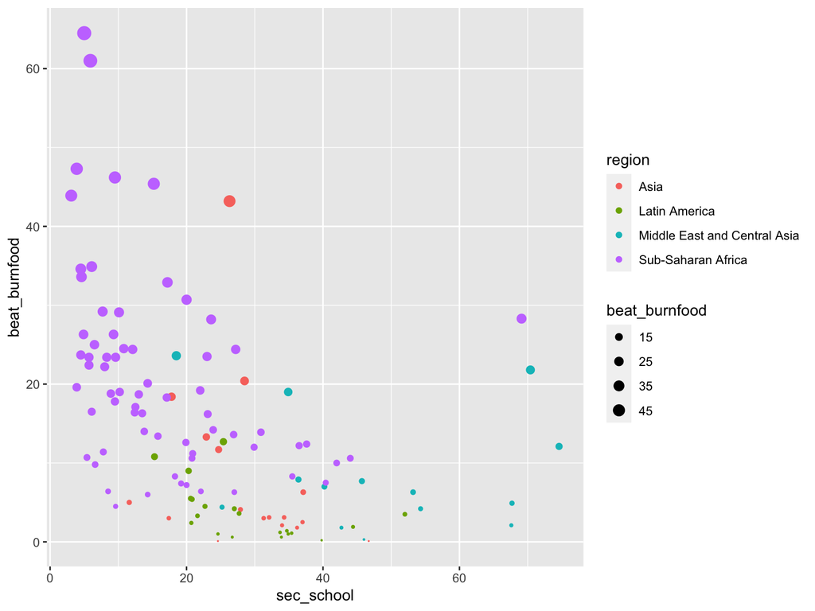

```r
ggplot(dhs_ipv) +
  geom_point(aes(x = sec_school, y = beat_burnfood, color = region, size = beat_burnfood)) +
  scale_size(range = c(0,4), breaks = c(15, 25, 35, 45))
```

## Les scales

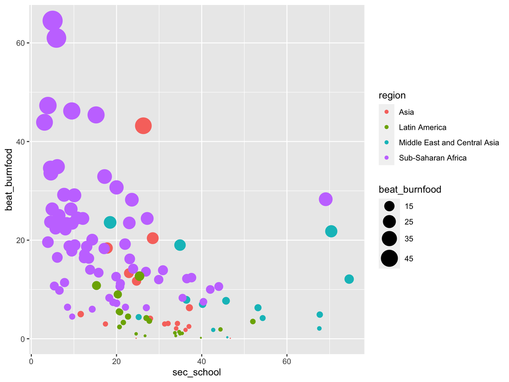

```r
ggplot(dhs_ipv) +
  geom_point(aes(x = sec_school, y = beat_burnfood, color = region, size = beat_burnfood)) +
  scale_size(range = c(0,10), breaks = c(15, 25, 35, 45))
```

## Les scales

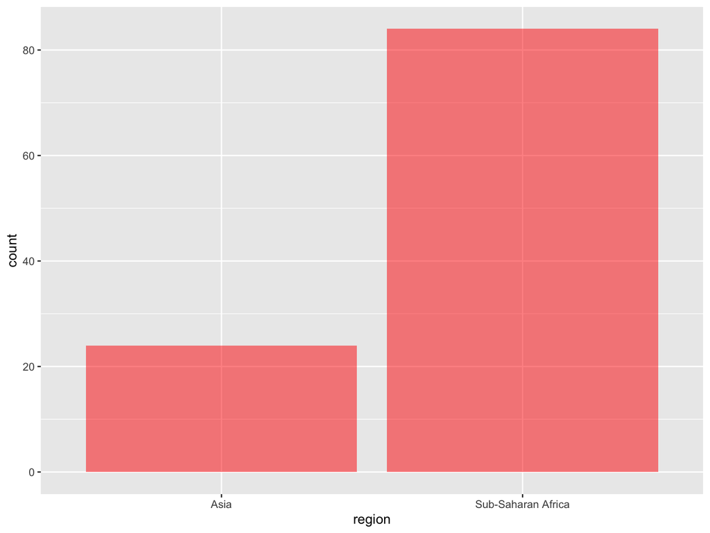

```r
ggplot(dhs_ipv) +
  geom_bar(aes(x = region), fill = "red", alpha = 0.5) +
  scale_x_discrete("region", limits = c("Asia", "Sub-Saharan Africa"))
```

## Les scales

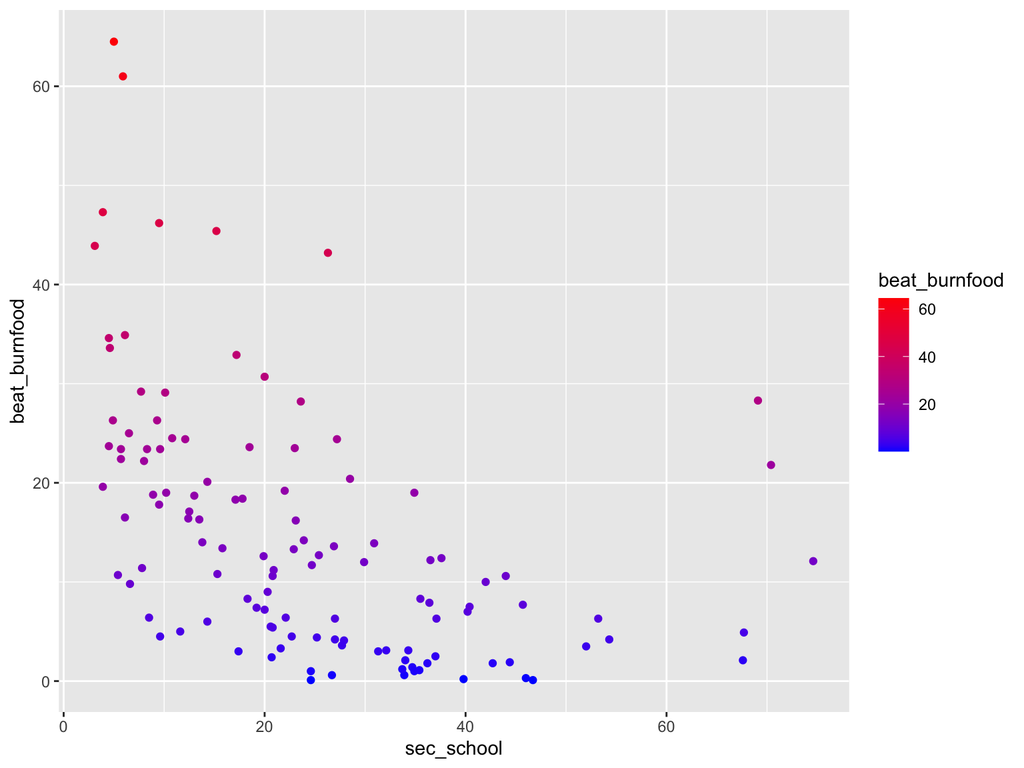

```r
ggplot(dhs_ipv) +
  geom_point(aes(x = sec_school, y = beat_burnfood, color = beat_burnfood)) +
  #geom_text(aes(x = sec_school, y = beat_burnfood, label = country, size = 3)) +
  scale_color_gradient("beat_burnfood", low = "blue", high = "red")
```

## Les scales

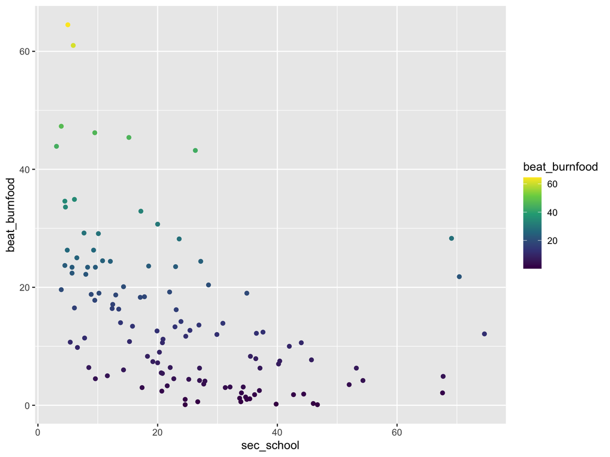

```r
ggplot(dhs_ipv) +
  geom_point(aes(x = sec_school, y = beat_burnfood, color = beat_burnfood)) +
  scale_color_viridis_c("beat_burnfood") # option = "inferno", ou "magma", ou "plasma")
```

# Les thèmes

## Les thèmes

https://ggplot2.tidyverse.org/reference/theme.html

- Les thèmes permettent de contrôler l’affichage de tous les éléments du graphique qui ne sont pas reliés aux données : `titres`, `grilles`, `fonds`, etc.

```r
a <- ggplot(dhs_ipv) +
  geom_histogram(aes(x = beat_burnfood)) +
  ggtitle("Histogramme") +
  xlab("Proportion des femmes qui estiment qu'une femme doit être battue") +
  ylab("Effectif") +
  theme_bw()
```

## Les thèmes

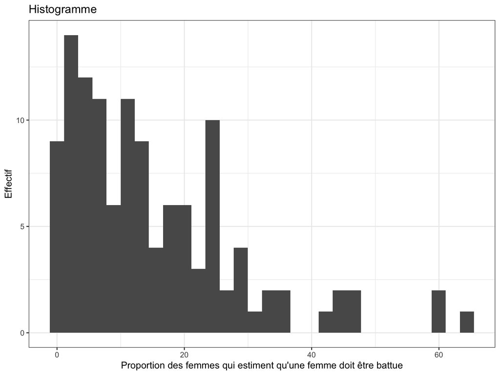

```r
a
```